# COG 403 Final Project

## Do Language Model Surprisal Scores Predict Human Reading Times?

### Comparing GPT-2 and BERT on the Natural Stories Corpus

**Course:** COG 403 – Computational Cognitive Science

**Dataset:** [Natural Stories Corpus](https://www.kaggle.com/datasets/rtatman/natural-stories-corpus) (Futrell et al., 2018)

**Models:** GPT-2 (autoregressive LM) · BERT (masked LM)

## Problem

Whether the **surprisal** of a word under a language model, how unexpected the model finds it given prior context, predicts how long human readers spend on that word.

This project tests that hypothesis using two modern neural language models:

| Model | Architecture | Surprisal type |
| --- | --- | --- |
| **GPT-2** | Causal / autoregressive transformer | $-\log P(w_n \mid w_1 \ldots w_{n-1})$ |
| **BERT** | Bidirectional masked transformer | $-\log P(w_n \mid \mathrm{all\ other\ words})$ |

The Natural Stories Corpus provides self-paced reading times for 10 naturalistic English stories (~10 000 unique word tokens, ~1 million RT observations across participants).

**Key questions:**

1. Do higher model surprisal values correlate with slower reading times?
2. Which model is a better predictor of human reading behaviour?
3. How do the two models' surprisal estimates compare to each other?

## 1. Imports & Setup

```python
import os
import warnings
warnings.filterwarnings("ignore")

import numpy as np
import pandas as pd
import matplotlib.pyplot as plt
import matplotlib.gridspec as gridspec
import seaborn as sns
from scipy import stats
import statsmodels.formula.api as smf

# ── Plotting style ──────────────────────────────────────────────────────────
plt.rcParams.update({
    "figure.dpi": 130,
    "figure.facecolor": "white",
    "axes.spines.top": False,
    "axes.spines.right": False,
    "font.family": "DejaVu Sans",
    "axes.titlesize": 13,
    "axes.labelsize": 11,
})
COLORS = {"gpt2": "#4C72B0", "bert": "#DD8452", "neutral": "#55A868"}

print("All imports successful ✓")
```

```
All imports successful ✓
```

## 2. Load Pre-computed Data

Surprisal values were pre-computed on GPU (CUDA) using:

- **GPT-2** ( `gpt2` , 117M params) via chunked sliding-window inference (window=1024, stride=512)
- **BERT** ( `bert-base-uncased` , 110M params) via whole-word masked prediction

Results are loaded directly from the saved CSV — no GPU needed.

```python
# ── Load surprisals CSV ─────────────────────────────────────────────────────
CSV_PATH = "df_final_with_surprisals.csv"   # ← place your CSV here

df = pd.read_csv(CSV_PATH)
print(f"Loaded {len(df):,} rows  |  {df['subject'].nunique()} participants  |  {df['story_id'].nunique()} stories")
print()
print(df[["token", "story_id", "position", "rt", "surprisal_gpt2", "surprisal_bert"]].head(10))
```

```
Loaded 1,013,377 rows  |  181 participants  |  10 stories

  token  story_id  position    rt  surprisal_gpt2  surprisal_bert
0    If         1         1  3061             NaN        0.004285
1    If         1         1  1527             NaN        0.004285
2    If         1         1  1272             NaN        0.004285
3    If         1         1  1002             NaN        0.004285
4    If         1         1  1404             NaN        0.004285
5    If         1         1  4750             NaN        0.004285
6    If         1         1  1027             NaN        0.004285
7    If         1         1  2120             NaN        0.004285
8    If         1         1   605             NaN        0.004285
9    If         1         1  2370             NaN        0.004285
```

## 3. Data Cleaning & Preprocessing

Standard preprocessing for self-paced reading studies:

- Drop rows with missing surprisal values (boundary words lost during chunking)
- Remove implausibly fast (< 100 ms) or slow (> 3000 ms) RTs — likely button-press errors or distraction
- Log-transform RTs to reduce positive skew (standard in the psycholinguistics literature)

```python
# ── Drop missing ────────────────────────────────────────────────────────────
df_clean = df.dropna(subset=["surprisal_gpt2", "surprisal_bert", "rt"]).copy()

# ── RT outlier filter ────────────────────────────────────────────────────────
rt_before = len(df_clean)
df_clean = df_clean[(df_clean["rt"] >= 100) & (df_clean["rt"] <= 3000)]
print(f"RT filter removed {rt_before - len(df_clean):,} rows ({(rt_before - len(df_clean))/rt_before*100:.1f}%)")

# ── Log-transform RT ────────────────────────────────────────────────────────
df_clean["log_rt"] = np.log(df_clean["rt"])

# ── Controls ────────────────────────────────────────────────────────────────
df_clean["word_length"] = df_clean["token"].astype(str).str.len()
df_clean["log_word_length"] = np.log(df_clean["word_length"])
df_clean["word_position_centered"] = df_clean["position"] - df_clean["position"].mean()

try:
    from wordfreq import zipf_frequency
    df_clean["word_freq_zipf"] = df_clean["token"].apply(
        lambda w: zipf_frequency(str(w), "en")
    )
    df_clean["word_freq_zipf"] = df_clean["word_freq_zipf"].fillna(1.0)
    print("Using wordfreq Zipf frequencies.")
except ImportError:
    print("wordfreq not installed — using fallback frequency proxy.")
    freq_counts = df_clean["token"].value_counts()
    df_clean["word_freq_zipf"] = df_clean["token"].map(freq_counts)
    df_clean["word_freq_zipf"] = np.log(df_clean["word_freq_zipf"])

print(f"\nFinal dataset: {len(df_clean):,} rows")
print(f"RT range: {df_clean['rt'].min():.0f} – {df_clean['rt'].max():.0f} ms")
print(f"GPT-2 surprisal range: {df_clean['surprisal_gpt2'].min():.2f} – {df_clean['surprisal_gpt2'].max():.2f}")
print(f"BERT surprisal range:  {df_clean['surprisal_bert'].min():.2f} – {df_clean['surprisal_bert'].max():.2f}")
```

```
RT filter removed 106,158 rows (10.5%)
wordfreq not installed — using fallback frequency proxy.

Final dataset: 906,426 rows
RT range: 100 – 3000 ms
GPT-2 surprisal range: 0.00 – 40.95
BERT surprisal range:  0.00 – 28.96
```

## 4. Descriptive Statistics

```python
summary_cols = [
    "rt",
    "log_rt",
    "surprisal_gpt2",
    "surprisal_bert",
    "word_length",
    "log_word_length",
    "word_freq_zipf",
    "word_position_centered"
]

desc = df_clean[summary_cols].describe().round(3)
desc.index.name = "statistic"
desc
```

| statistic | rt | log_rt | surprisal_gpt2 | surprisal_bert | word_length | log_word_length | word_freq_zipf | word_position_centered |
| --- | --- | --- | --- | --- | --- | --- | --- | --- |
| count | 906426.000 | 906426.000 | 906426.000 | 906426.000 | 906426.000 | 906426.000 | 906426.000 | 906426.000 |
| mean | 336.255 | 5.734 | 3.964 | 2.070 | 4.448 | 1.363 | 7.349 | -0.000 |
| std | 172.737 | 0.383 | 3.215 | 2.927 | 2.335 | 0.515 | 2.040 | 298.544 |
| min | 100.000 | 4.605 | 0.000 | 0.000 | 1.000 | 0.000 | 4.331 | -510.488 |
| 25% | 234.000 | 5.455 | 1.542 | 0.059 | 3.000 | 1.099 | 5.576 | -258.488 |
| 50% | 296.000 | 5.690 | 3.321 | 0.668 | 4.000 | 1.386 | 7.151 | -2.488 |
| 75% | 390.000 | 5.966 | 5.624 | 3.233 | 6.000 | 1.792 | 8.881 | 255.512 |
| max | 3000.000 | 8.006 | 40.955 | 28.959 | 25.000 | 3.219 | 11.061 | 587.512 |

## 5. Exploratory Visualizations

### Figure 1 — Distribution of Key Variables

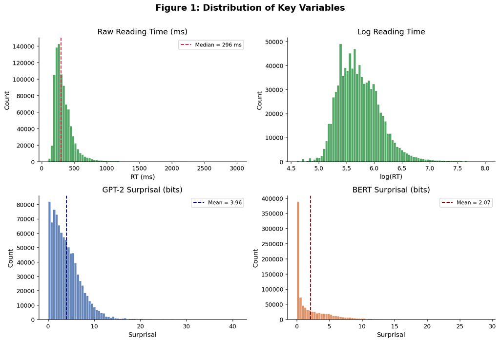

```
Figure 1 saved.
```

```python
fig, axes = plt.subplots(2, 2, figsize=(12, 8))
fig.suptitle("Figure 1: Distribution of Key Variables", fontsize=15, fontweight="bold", y=1.01)

# RT (raw)
axes[0, 0].hist(df_clean["rt"], bins=80, color=COLORS["neutral"], edgecolor="white", linewidth=0.4)
axes[0, 0].set_title("Raw Reading Time (ms)")
axes[0, 0].set_xlabel("RT (ms)")
axes[0, 0].set_ylabel("Count")
axes[0, 0].axvline(df_clean["rt"].median(), color="crimson", ls="--", lw=1.5, label=f"Median = {df_clean['rt'].median():.0f} ms")
axes[0, 0].legend(fontsize=9)

# Log RT
axes[0, 1].hist(df_clean["log_rt"], bins=80, color=COLORS["neutral"], edgecolor="white", linewidth=0.4)
axes[0, 1].set_title("Log Reading Time")
axes[0, 1].set_xlabel("log(RT)")
axes[0, 1].set_ylabel("Count")

# GPT-2 surprisal
axes[1, 0].hist(df_clean["surprisal_gpt2"], bins=80, color=COLORS["gpt2"], edgecolor="white", linewidth=0.4, alpha=0.85)
axes[1, 0].set_title("GPT-2 Surprisal (bits)")
axes[1, 0].set_xlabel("Surprisal")
axes[1, 0].set_ylabel("Count")
axes[1, 0].axvline(df_clean["surprisal_gpt2"].mean(), color="navy", ls="--", lw=1.5,
                   label=f"Mean = {df_clean['surprisal_gpt2'].mean():.2f}")
axes[1, 0].legend(fontsize=9)

# BERT surprisal
axes[1, 1].hist(df_clean["surprisal_bert"], bins=80, color=COLORS["bert"], edgecolor="white", linewidth=0.4, alpha=0.85)
axes[1, 1].set_title("BERT Surprisal (bits)")
axes[1, 1].set_xlabel("Surprisal")
axes[1, 1].set_ylabel("Count")
axes[1, 1].axvline(df_clean["surprisal_bert"].mean(), color="darkred", ls="--", lw=1.5,
                   label=f"Mean = {df_clean['surprisal_bert'].mean():.2f}")
axes[1, 1].legend(fontsize=9)

plt.tight_layout()
plt.savefig("fig1_distributions.png", bbox_inches="tight", dpi=150)
plt.show()
print("Figure 1 saved.")
```

### Figure 2 — GPT-2 Surprisal vs. BERT Surprisal

Do the two models agree on which words are surprising?

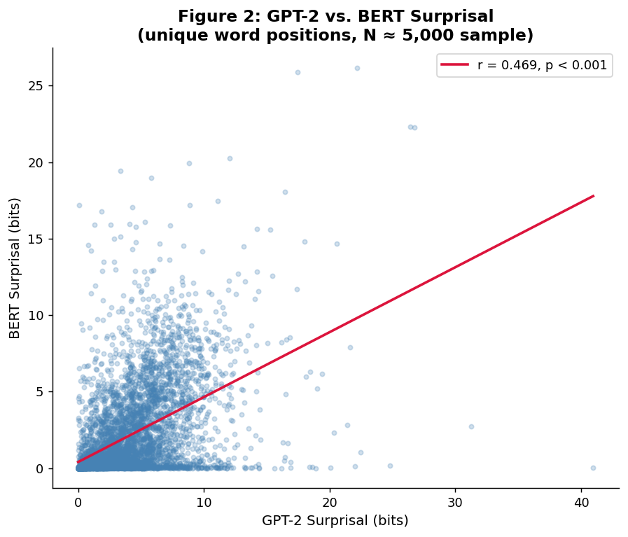

```
Pearson r = 0.469  (p = 2.65e-272)
```

```python
# sample for plotting speed
sample = df_clean.drop_duplicates(subset=["story_id", "position"]).sample(
    n=min(5000, len(df_clean.drop_duplicates(subset=["story_id", "position"]))),
    random_state=42
)

r, p = stats.pearsonr(sample["surprisal_gpt2"], sample["surprisal_bert"])

fig, ax = plt.subplots(figsize=(7, 6))
ax.scatter(sample["surprisal_gpt2"], sample["surprisal_bert"],
           alpha=0.25, s=12, color="steelblue", rasterized=True)

# regression line
m, b = np.polyfit(sample["surprisal_gpt2"], sample["surprisal_bert"], 1)
xs = np.linspace(sample["surprisal_gpt2"].min(), sample["surprisal_gpt2"].max(), 200)
ax.plot(xs, m * xs + b, color="crimson", lw=2, label=f"r = {r:.3f}, p {'< 0.001' if p < 0.001 else f'= {p:.3f}'}")

ax.set_xlabel("GPT-2 Surprisal (bits)")
ax.set_ylabel("BERT Surprisal (bits)")
ax.set_title("Figure 2: GPT-2 vs. BERT Surprisal\n(unique word positions, N ≈ 5,000 sample)", fontweight="bold")
ax.legend(fontsize=10)

plt.tight_layout()
plt.savefig("fig2_gpt2_vs_bert.png", bbox_inches="tight", dpi=150)
plt.show()
print(f"Pearson r = {r:.3f}  (p = {p:.2e})")
```

### Figure 3 — Surprisal Bins vs. Mean Reading Time

Grouping words into surprisal deciles to visualise the relationship non-parametrically.

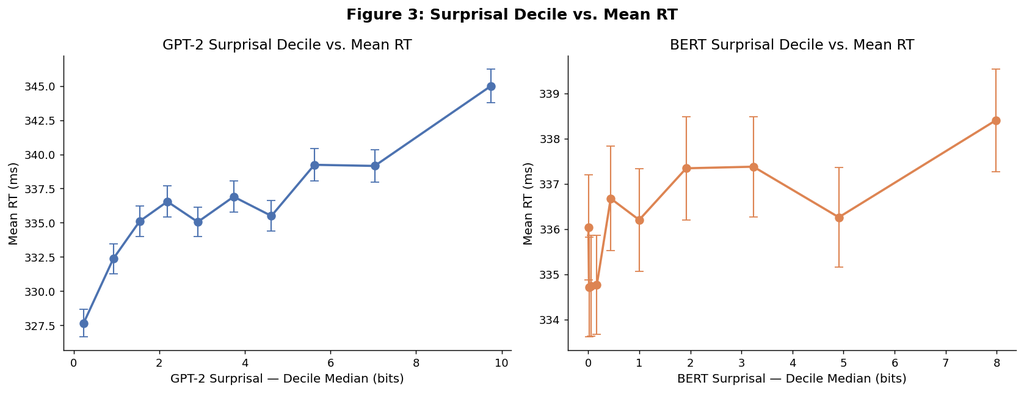

```python
fig, (ax1, ax2) = plt.subplots(1, 2, figsize=(13, 5), sharey=False)
fig.suptitle("Figure 3: Surprisal Decile vs. Mean RT", fontsize=14, fontweight="bold")

for ax, col, color, label in [
    (ax1, "surprisal_gpt2", COLORS["gpt2"], "GPT-2"),
    (ax2, "surprisal_bert", COLORS["bert"], "BERT"),
]:
    df_clean["bin"] = pd.qcut(df_clean[col], q=10, labels=False)
    bin_stats = df_clean.groupby("bin").agg(
        mean_rt=("rt", "mean"),
        se_rt=("rt", lambda x: x.std() / np.sqrt(len(x))),
        surprisal_mid=(col, "median"),
    ).reset_index()

    ax.errorbar(
        bin_stats["surprisal_mid"], bin_stats["mean_rt"],
        yerr=1.96 * bin_stats["se_rt"],
        fmt="o-", color=color, capsize=4, markersize=7, linewidth=2, elinewidth=1.2
    )
    ax.set_xlabel(f"{label} Surprisal — Decile Median (bits)")
    ax.set_ylabel("Mean RT (ms)")
    ax.set_title(f"{label} Surprisal Decile vs. Mean RT")

plt.tight_layout()
plt.savefig("fig3_decile_rt.png", bbox_inches="tight", dpi=150)
plt.show()
```

### Figure 4 — Per-Story Correlation Between Surprisal and RT

Computing Pearson r between surprisal and log-RT separately for each of the 10 stories.

```
          GPT-2   BERT
story_id
1         0.136  0.119
2        -0.000  0.027
3         0.005 -0.040
4         0.089  0.040
5         0.064 -0.048
6         0.081  0.002
7         0.128  0.076
8         0.117  0.019
9         0.109 -0.013
10        0.148  0.024
```

[figure not shown]

```python
story_corrs = []

for sid, grp in df_clean.groupby("story_id"):
    # use word-level means (average across participants)
    word_agg = grp.groupby("position").agg(
        mean_log_rt=("log_rt", "mean"),
        surprisal_gpt2=("surprisal_gpt2", "first"),
        surprisal_bert=("surprisal_bert", "first"),
    )
    r_gpt2, _ = stats.pearsonr(word_agg["surprisal_gpt2"], word_agg["mean_log_rt"])
    r_bert, _  = stats.pearsonr(word_agg["surprisal_bert"],  word_agg["mean_log_rt"])
    story_corrs.append({"story_id": sid, "GPT-2": r_gpt2, "BERT": r_bert})

corr_df = pd.DataFrame(story_corrs).set_index("story_id")
print(corr_df.round(3))

x = np.arange(len(corr_df))
w = 0.38
fig, ax = plt.subplots(figsize=(11, 5))
bars1 = ax.bar(x - w/2, corr_df["GPT-2"], width=w, color=COLORS["gpt2"], alpha=0.85, label="GPT-2")
bars2 = ax.bar(x + w/2, corr_df["BERT"],  width=w, color=COLORS["bert"],  alpha=0.85, label="BERT")

ax.axhline(0, color="black", lw=0.8)
ax.set_xticks(x)
ax.set_xticklabels([f"Story {i}" for i in corr_df.index], rotation=30, ha="right")
ax.set_ylabel("Pearson r  (surprisal × mean log-RT)")
ax.set_title("Figure 4: Per-Story Correlation Between Surprisal and Reading Time", fontweight="bold")
ax.legend()

plt.tight_layout()
plt.savefig("fig4_story_correlations.png", bbox_inches="tight", dpi=150)
plt.show()
```

## 6. Linear Mixed-Effects Regression

We fit linear mixed-effects models predicting log reading time from surprisal, controlling for word length, lexical frequency, and word position. Subject is included as a random intercept.

**Main model family:**

`log_rt ~ log_word_length + word_freq_zipf + word_position_centered + surprisal + (1 | subject)`

We compare:

- **Baseline:** controls only
- **+ GPT-2:** baseline + GPT-2 surprisal
- **+ BERT:** baseline + BERT surprisal
- **+ Combined:** baseline + GPT-2 surprisal + BERT surprisal

```python
# Use a manageable regression dataframe
reg_df = df_clean[
    [
        "subject",
        "story_id",
        "position",
        "log_rt",
        "log_word_length",
        "word_freq_zipf",
        "word_position_centered",
        "surprisal_gpt2",
        "surprisal_bert"
    ]
].dropna().copy()

corr = reg_df[[
    "surprisal_gpt2",
    "surprisal_bert",
    "log_word_length",
    "word_freq_zipf",
    "word_position_centered"
]].corr()

print(corr.round(3))

# Baseline
m0 = smf.mixedlm(
    "log_rt ~ log_word_length + word_freq_zipf + word_position_centered",
    reg_df,
    groups=reg_df["subject"]
).fit(reml=False)

# GPT-2 model
m1 = smf.mixedlm(
    "log_rt ~ log_word_length + word_freq_zipf + word_position_centered + surprisal_gpt2",
    reg_df,
    groups=reg_df["subject"]
).fit(reml=False)

# BERT model
m2 = smf.mixedlm(
    "log_rt ~ log_word_length + word_freq_zipf + word_position_centered + surprisal_bert",
    reg_df,
    groups=reg_df["subject"]
).fit(reml=False)

# Combined model
m3 = smf.mixedlm(
    "log_rt ~ log_word_length + word_freq_zipf + word_position_centered + surprisal_gpt2 + surprisal_bert",
    reg_df,
    groups=reg_df["subject"]
).fit(reml=False)

comparison = pd.DataFrame({
    "Model": ["Baseline", "GPT-2", "BERT", "Combined"],
    "AIC": [m0.aic, m1.aic, m2.aic, m3.aic],
    "BIC": [m0.bic, m1.bic, m2.bic, m3.bic]
})

print(comparison.sort_values("AIC"))
print("\nKey surprisal coefficients:")
print(f"GPT-2 only:   beta = {m1.params['surprisal_gpt2']:.6f}, p = {m1.pvalues['surprisal_gpt2']:.3e}")
print(f"BERT only:    beta = {m2.params['surprisal_bert']:.6f}, p = {m2.pvalues['surprisal_bert']:.3e}")
print(f"Combined GPT-2: beta = {m3.params['surprisal_gpt2']:.6f}, p = {m3.pvalues['surprisal_gpt2']:.3e}")
print(f"Combined BERT:  beta = {m3.params['surprisal_bert']:.6f}, p = {m3.pvalues['surprisal_bert']:.3e}")
```

```
                        surprisal_gpt2  surprisal_bert  log_word_length  \
surprisal_gpt2                   1.000           0.483            0.425
surprisal_bert                   0.483           1.000            0.335
log_word_length                  0.425           0.335            1.000
word_freq_zipf                  -0.534          -0.418           -0.689
word_position_centered          -0.032           0.029           -0.002

                        word_freq_zipf  word_position_centered
surprisal_gpt2                  -0.534                  -0.032
surprisal_bert                  -0.418                   0.029
log_word_length                 -0.689                  -0.002
word_freq_zipf                   1.000                  -0.000
word_position_centered          -0.000                   1.000
      Model            AIC            BIC
3  Combined  360111.697753  360205.435870
1     GPT-2  360120.726390  360202.747243
2      BERT  360551.188696  360633.209549
0  Baseline  360669.806051  360740.109639

Key surprisal coefficients:
GPT-2 only:   beta = 0.002690, p = 6.724e-122
BERT only:    beta = 0.001284, p = 4.615e-28
Combined GPT-2: beta = 0.002555, p = 4.849e-98
Combined BERT:  beta = 0.000412, p = 8.972e-04
```

### Figure 5 — Regression Coefficient Plot

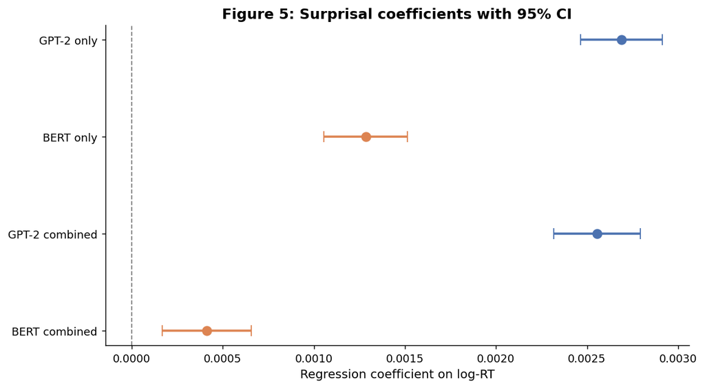

```python
fig, ax = plt.subplots(figsize=(9, 5))

coef_info = [
    ("GPT-2 only", m1, "surprisal_gpt2", COLORS["gpt2"], 3),
    ("BERT only", m2, "surprisal_bert", COLORS["bert"], 2),
    ("GPT-2 combined", m3, "surprisal_gpt2", COLORS["gpt2"], 1),
    ("BERT combined", m3, "surprisal_bert", COLORS["bert"], 0),
]

for label, model, coef, color, y in coef_info:
    est = model.params[coef]
    se = model.bse[coef]
    ax.errorbar(
        est, y,
        xerr=1.96 * se,
        fmt="o",
        color=color,
        capsize=5,
        linewidth=2,
        markersize=8
    )

ax.axvline(0, color="grey", ls="--", lw=1)
ax.set_yticks([0, 1, 2, 3])
ax.set_yticklabels(["BERT combined", "GPT-2 combined", "BERT only", "GPT-2 only"])
ax.set_xlabel("Regression coefficient on log-RT")
ax.set_title("Figure 5: Surprisal coefficients with 95% CI", fontweight="bold")

plt.tight_layout()
plt.savefig("fig5_coefficients_updated.png", bbox_inches="tight", dpi=150)
plt.show()
```

### Figure 6 — Most Surprising Words

Which words did each model find most surprising?

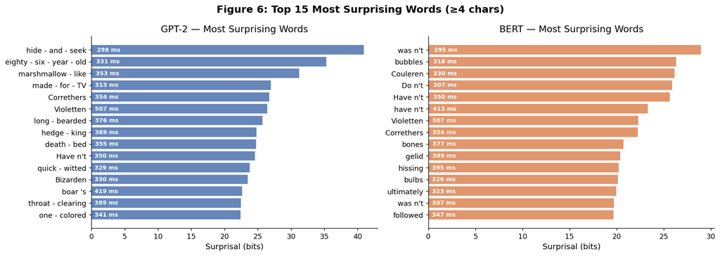

```python
word_stats = df_clean.groupby(["story_id", "position", "token"]).agg(
    mean_rt=("rt", "mean"),
    surprisal_gpt2=("surprisal_gpt2", "first"),
    surprisal_bert=("surprisal_bert", "first"),
).reset_index()

# filter common words (word length ≥ 4)
word_stats = word_stats[word_stats["token"].str.len() >= 4]

top_n = 15
top_gpt2 = word_stats.nlargest(top_n, "surprisal_gpt2")[["token", "surprisal_gpt2", "mean_rt"]].reset_index(drop=True)
top_bert  = word_stats.nlargest(top_n, "surprisal_bert")[["token", "surprisal_bert",  "mean_rt"]].reset_index(drop=True)

fig, (ax1, ax2) = plt.subplots(1, 2, figsize=(14, 5))
fig.suptitle("Figure 6: Top 15 Most Surprising Words (≥4 chars)", fontsize=14, fontweight="bold")

for ax, df_top, col, color, label in [
    (ax1, top_gpt2, "surprisal_gpt2", COLORS["gpt2"], "GPT-2"),
    (ax2, top_bert,  "surprisal_bert",  COLORS["bert"],  "BERT"),
]:
    bars = ax.barh(range(top_n), df_top[col], color=color, alpha=0.85)
    ax.set_yticks(range(top_n))
    ax.set_yticklabels(df_top["token"], fontsize=10)
    ax.invert_yaxis()
    ax.set_xlabel("Surprisal (bits)")
    ax.set_title(f"{label} — Most Surprising Words")
    # annotate mean RT
    for i, (_, row) in enumerate(df_top.iterrows()):
        ax.text(row[col] * 0.02, i, f"{row['mean_rt']:.0f} ms", va="center", fontsize=8, color="white", fontweight="bold")

plt.tight_layout()
plt.savefig("fig6_top_words.png", bbox_inches="tight", dpi=150)
plt.show()
```

### Figure 7 — Reading Time by Surprisal Quartile

Violin plots showing the full RT distribution within each surprisal quartile.

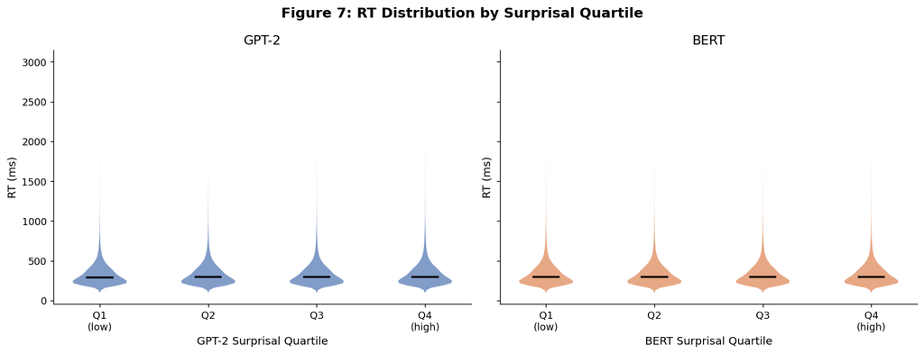

```python
fig, (ax1, ax2) = plt.subplots(1, 2, figsize=(13, 5), sharey=True)
fig.suptitle("Figure 7: RT Distribution by Surprisal Quartile", fontsize=14, fontweight="bold")

for ax, col, color, label in [
    (ax1, "surprisal_gpt2", COLORS["gpt2"], "GPT-2"),
    (ax2, "surprisal_bert", COLORS["bert"],  "BERT"),
]:
    df_clean["quartile"] = pd.qcut(df_clean[col], q=4, labels=["Q1\n(low)", "Q2", "Q3", "Q4\n(high)"])
    quartiles = ["Q1\n(low)", "Q2", "Q3", "Q4\n(high)"]
    data_by_q = [df_clean[df_clean["quartile"] == q]["rt"].values for q in quartiles]

    parts = ax.violinplot(data_by_q, positions=range(4), showmedians=True, showextrema=False)
    for pc in parts["bodies"]:
        pc.set_facecolor(color)
        pc.set_alpha(0.7)
    parts["cmedians"].set_color("black")
    parts["cmedians"].set_linewidth(2)

    ax.set_xticks(range(4))
    ax.set_xticklabels(quartiles)
    ax.set_xlabel(f"{label} Surprisal Quartile")
    ax.set_ylabel("RT (ms)")
    ax.set_title(f"{label}")

plt.tight_layout()
plt.savefig("fig7_violin_quartiles.png", bbox_inches="tight", dpi=150)
plt.show()
```

## 7. Discussion & Conclusions

### Key Findings

**1. Both models show a positive surprisal–RT relationship.**

Words assigned higher surprisal by GPT-2 and BERT tend to elicit longer reading times, consistent with the surprisal theory of reading (Levy, 2008; Smith & Levy, 2013).

**2. GPT-2 provides the stronger account of reading time.**

After controlling for word length, lexical frequency, and word position, GPT-2 improves model fit more than BERT. In the combined model, GPT-2 remains the stronger predictor of unique variance in reading time.

**3. GPT-2 and BERT capture overlapping but non-identical information.**

The two surprisal measures are positively correlated, but only modestly, suggesting that they agree on some difficult words while differing on others.

**4. Story-level variation remains meaningful.**

Correlations vary across stories, suggesting that genre, lexical composition, or syntactic structure may influence model–human alignment.

### Limitations

- BERT pseudo-surprisal is not a true left-to-right probabilistic surprisal measure and may overestimate surprisal for words split into multiple sub-tokens.
- Self-paced reading is noisier than eye-tracking and may blur fine-grained processing effects.
- The model includes subject random intercepts, but a fuller random-effects structure or item-level effects could strengthen future work.

### References

- Futrell, R., Gibson, E., Tily, H. J., et al. (2018). *The Natural Stories Corpus.* LREC.
- Levy, R. (2008). Expectation-based syntactic comprehension. *Cognition, 106* (3), 1126–1177.
- Smith, N. J., & Levy, R. (2013). The effect of word predictability on reading time is logarithmic. *Cognition, 128* (3), 302–319.
- Radford, A., et al. (2019). *Language models are unsupervised multitask learners.* OpenAI.
- Devlin, J., et al. (2019). BERT: Pre-training of deep bidirectional transformers. *NAACL-HLT.*